# Problem Set 3 - Antworten

Christoph Nguyen

6/29/2020

# Setup und Daten reinigen

Wir nutzen die Daten des Bundestag Roll call vote data (BTVote) von https://dataverse.harvard.edu/dataverse/btvote. Die wirkliche Aufbereitung der Daten besprechen war optional und wird in einem gesonderten Dokument erklärt.

```r
  #Load Packages
  library(tidyverse)
  library(ggthemes)
```

```r
  library(haven)
  library(knitr)
  library(sjPlot) #for nice rmarkdown tables
  #Read in Data###
  DATA<-read_dta("https://github.com/cgnguyen/parlament_in_r/blob/master/Problem_Set_3/problem_set_3.dta?raw=true")

  ####*Data cleaning####
  DATA$mandate<-as_factor(DATA$mandate)

  DATA$party_elec<-as_factor(DATA$party_elec)
```

#Frage 1: Wahlverhalten und der Sicherheit des Wahlkreises

Gibt es ein Verhältnis zwischen abweichendem Wahlverhalten und der Sicherheit des Wahlkreises (elecsafe_overall)?

### Graphische Darstellung

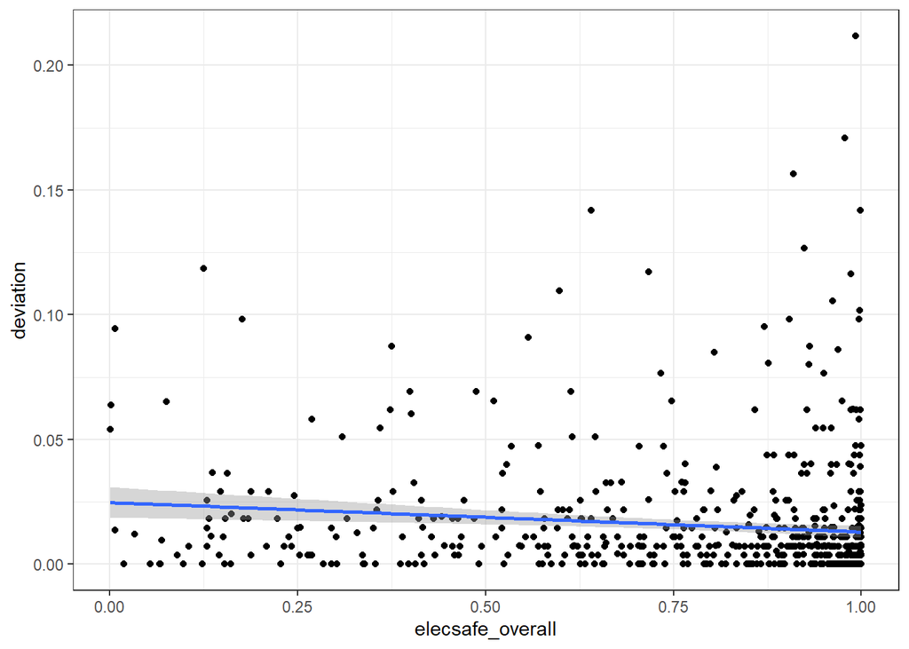

```r
 DATA %>%
        ggplot()+
        aes(x=elecsafe_overall, y=deviation)+
        geom_point()+
        theme_bw()+
        geom_smooth(method="lm")
```

### Einfache Regression

```r
  mod_1 <- lm (deviation ~ elecsafe_overall, data=DATA)

  summary(mod_1)
```

```
##
## Call:
## lm(formula = deviation ~ elecsafe_overall, data = DATA)
##
## Residuals:
##       Min        1Q    Median        3Q       Max
## -0.024555 -0.013006 -0.007846  0.001461  0.198627
##
## Coefficients:
##                   Estimate Std. Error t value Pr(>|t|)
## (Intercept)       0.024776   0.003117   7.948 8.01e-15 ***
## elecsafe_overall -0.011813   0.003698  -3.195  0.00147 **
## ---
## Signif. codes:  0 '***' 0.001 '**' 0.01 '*' 0.05 '.' 0.1 ' ' 1
##
## Residual standard error: 0.02476 on 672 degrees of freedom
## Multiple R-squared:  0.01496,    Adjusted R-squared:  0.01349
## F-statistic: 10.21 on 1 and 672 DF,  p-value: 0.001466
```

Tab_model um die Tabellen etwas “schöner” zu machen.

```r
  tab_model(mod_1,p.style="stars")
```

deviation

Predictors

Estimates

CI

(Intercept)

0.02 ***

0.02 – 0.03

overall electoral safety  
in both tiers

-0.01 **

-0.02 – -0.00

Observations

674

R<sup>2</sup> / R<sup>2</sup> adjusted

0.015 / 0.013

- p<0.05 ** p<0.01 *** p<0.001

Was bedeutet elecsafe_overall? Codebook Referenz ist [Stoffel & Sieberer 2017](https://www.tandfonline.com/doi/full/10.1080/01402382.2017.1400273). Herleitung etwas kompliziert, aber Bedeutung ist klar. Chance der Wiederwahl auf einer Skala von 0 bis 1.

Abhängige Variable ist Prozentzahl der abweichenden Wahl.

Interpretation: Wenn die Sicherheit des Wahlkreis um eine Einheit (also von 0 % zu 100%) steigt, sinkt das abweichende Wahlverhalten um ca. 1.1 % (-0.0118). Der Effekt ist statistische signifikant. Das heißt, wenn es kein Verhältnis zwischen Sicherheit und geben würde (Koeffizient ist 0) würden wir diesen Koeffizienten in weniger als 1% der Fälle beobachten (- wenn OLS Annahmen erfüllt sind)

# Frage 2: Verhältnis für Wahlkreissicherheit und Fraktionszugehörigkeit.

### Modell

[output not shown]

Für jeden Punkt “Sicherheit” sinkt das abweichende Wahlverhalten um ca 1%. Es gibt auch Unterschiede zwischen den Fraktionen. Im Vergleich zur SPD, gibt es bei der CDU, CSU und der LInken ca. 1% weniger Abweichungen. Bei der FDP sind es sogar 2% weniger. Bei den Grünen sind es ca 1% mehr.

### Visualsierung 1: Basiert auf dem Model

[output not shown]

### Visualsierung 2: Für jede Partei

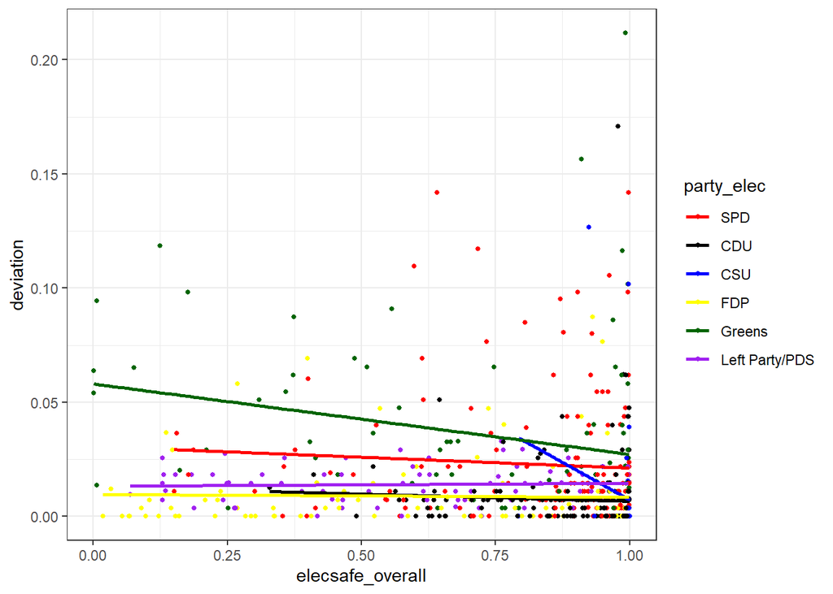

```r
 DATA%>%
        select(deviation,elecsafe_overall,party_elec)%>%
        drop_na()%>%
        ggplot()+
          aes(x=elecsafe_overall, y=deviation, group=party_elec, color=party_elec)+
          geom_point(alpha=1, size=1)+
          geom_smooth(method="lm", se=F)+
          scale_color_manual(values=c("red","black","blue","yellow","dark green", "                               purple"))+
          theme_bw()
```

# Frage 3: Mandatstyp und Sicherheit

```r
  mod_3 <- lm (deviation ~ elecsafe_overall+mandate, data=DATA)
  tab_model(mod_3,p.style="stars")
```

deviation

Predictors

Estimates

CI

(Intercept)

0.02 ***

0.02 – 0.03

overall electoral safety  
in both tiers

-0.01

-0.02 – 0.00

type of mandate held by  
MP: district mandate

-0.01 **

-0.01 – -0.00

Observations

674

R<sup>2</sup> / R<sup>2</sup> adjusted

0.027 / 0.024

- p<0.05 ** p<0.01 *** p<0.001

Distriktmandate (im Vergleich zu einem Listenmandat) haben statistisch signifikant weniger Abweichungen. Allerdings ist nun die Sicherheit des Wahlkreises nicht mehr statistisch relevant.